# R Programming Basics

Jeffrey Chrabaszcz  
2 January 2014

### Outline

1. Why use R?
2. RStudio
3. Data structures
4. Indexing
5. Functions
6. Data interrogation
7. Loops (or not)
8. Custom functions
9. Writing/reading data
10. Plots

### Why use R?

*“Excel hides your calculations and shows you the result. R does the opposite.”*

### Why use R?

- You can do *anything*
- Free and Open Source
- DRY
- Graphics
- Principle of equivalent difficulty
- User community

### RStudio

- **I**ntegrated **D**evelopment **E**nvironment for R
- looks like the MATLAB interface
- keeps a lot of information on-screen, avoiding some typing
- saves your graphs!

### Console

The console is like a sandbox - it's where you can interact with R directly and a good place to troubleshoot code. Nothing that you write here is saved, though, so you should do most of your coding in the editor and run it from there.

### Console commands

**dir** tells you what files are in your current directory.

```r
dir("~")
```

```
 [1] "Applications" "Desktop"      "Documents"    "Downloads"
 [5] "Dropbox"      "figure"       "gemmR"        "Google Drive"
 [9] "Library"      "Movies"       "Music"        "Pictures"
[13] "Public"       "R-dev"        "stan"         "test-figure"
[17] "texmf"
```

### Console commands

**getwd** tells you your current working directory. If you're using RStudio, this is the file path to the right of the console label.

```r
getwd()
```

```
[1] "/Users/jchrszcz/Dropbox/Statistics"
```

### Console commands

**setwd** will changes the working directory. This can make it easier to work with a bunch of files in a given location. Windows users must switch backslashes to forward slashes

```r
current.wd <- getwd()
setwd(current.wd)
getwd()
```

```
[1] "/Users/jchrszcz/Dropbox/Statistics"
```

### Console commands

**ls** tells you the variables currently in the R workspace.

```r
ls()
```

```
[1] "current.wd"
```

### Packaging

**R** uses a variety of add-on functions found in *packages*. These differ from R scripts in that they're relatively immutable. Installed packages must be separately updated to change the functions in them.

**install.packages** is self-explanatory. You only need to install packages once, even though you'll have to load them for each session of R.

```r
install.packages("ggplot2")
```

**library** will load installed packages. This must be done for each R session.

```r
library(ggplot2)
```

### Data structures

- vector
- matrix
- data.frame

### Vector

```r
my.vector <- c(1, 2, 2, 3, 3, 3, 4, 4, 5)
my.vector
```

```
[1] 1 2 2 3 3 3 4 4 5
```

```r
mixed.vec <- c(1, 2, "apple", "banana", 6)
mixed.vec
```

```
[1] "1"      "2"      "apple"  "banana" "6"
```

### An aside for modes

- numeric
- character
- logical
- **factor**

### Matrix

Matrices are 2-dimensional, they have rows and columns, and all elements of a matrix must be of the same type, (numbers or strings, for example). Matrices are created with the **matrix** function. The first argument is the set of entries for the matrix. Two possible arguments are *nrow* and *ncol*, which specify the number of rows or columns.

```r
my.matrix <- matrix(c(1:9), ncol = 3)
my.matrix
```

```
     [,1] [,2] [,3]
[1,]    1    4    7
[2,]    2    5    8
[3,]    3    6    9
```

### Data Frame

```r
bacon <- rep(c(0,1), times = 2, each = 2)
pancakes <- rep(c("blueberry","chocolate chip"), each = 4)
breakfast <- data.frame(bacon, pancakes, quality = 1:8)
breakfast
```

```
  bacon       pancakes quality
1     0      blueberry       1
2     0      blueberry       2
3     1      blueberry       3
4     1      blueberry       4
5     0 chocolate chip       5
6     0 chocolate chip       6
7     1 chocolate chip       7
8     1 chocolate chip       8
```

### Indexing

- square braces, []
- dollar sign, $
- at symbol, @
  - we won't really use @ very much, if at all

### vectors

```r
my.vector[4]
```

```
[1] 3
```

```r
my.vector[1:4]
```

```
[1] 1 2 2 3
```

### matrices

```r
my.matrix[2]
```

```
[1] 2
```

```r
my.matrix[2,2]
```

```
[1] 5
```

### more matrices

```r
my.matrix[,2]
```

```
[1] 4 5 6
```

### data.frames

```r
breakfast$bacon
```

```
[1] 0 0 1 1 0 0 1 1
```

```r
breakfast$bacon[1]
```

```
[1] 0
```

### data.frames

```r
breakfast[1]
```

```
  bacon
1     0
2     0
3     1
4     1
5     0
6     0
7     1
8     1
```

```r
breakfast[,1]
```

```
[1] 0 0 1 1 0 0 1 1
```

### data.frames

```r
breakfast[-2]
```

```
  bacon quality
1     0       1
2     0       2
3     1       3
4     1       4
5     0       5
6     0       6
7     1       7
8     1       8
```

```r
breakfast[2,3]
```

```
[1] 2
```

### Functions

take some input, produce an output

```r
1 + 2
```

```
[1] 3
```

```r
3 + 4 * 2
```

```
[1] 11
```

```r
1:5
```

```
[1] 1 2 3 4 5
```

### two kinds of functions

- positions are all the same
- positions correspond to named arguments

### first kind

```r
sum(1, 2, 3)
```

```
[1] 6
```

```r
c(1,2,3,4,5)
```

```
[1] 1 2 3 4 5
```

### second (more common) kind

```r
a <- 1:5
mean(a)
```

```
[1] 3
```

```r
mean(1,2,3,4,5)
```

```
[1] 1
```

### Data interrogation

- many ways to *see* data
- usually you don't want all of it at once
- sometimes you want some kind of summary or description

### discovering structure

```r
mode(breakfast)
```

```
[1] "list"
```

```r
class(breakfast)
```

```
[1] "data.frame"
```

### discovering structure

```r
str(breakfast)
```

```
'data.frame':   8 obs. of  3 variables:
 $ bacon   : num  0 0 1 1 0 0 1 1
 $ pancakes: Factor w/ 2 levels "blueberry","chocolate chip": 1 1 1 1 2 2 2 2
 $ quality : int  1 2 3 4 5 6 7 8
```

### discovering structure

```r
summary(breakfast)
```

```
     bacon               pancakes    quality
 Min.   :0.0   blueberry     :4   Min.   :1.00
 1st Qu.:0.0   chocolate chip:4   1st Qu.:2.75
 Median :0.5                      Median :4.50
 Mean   :0.5                      Mean   :4.50
 3rd Qu.:1.0                      3rd Qu.:6.25
 Max.   :1.0                      Max.   :8.00
```

### seeing raw data

```r
head(breakfast)
```

```
  bacon       pancakes quality
1     0      blueberry       1
2     0      blueberry       2
3     1      blueberry       3
4     1      blueberry       4
5     0 chocolate chip       5
6     0 chocolate chip       6
```

**tail(breakfast)** also works, with predictable results

### Loops (or not)

Loops are the reason that programming is powerful. Any time you need to perform the same calculation a number of times, loops make your life easier.

R has a lot of implicit loops, for example:

```r
a <- 1:10
a
```

```
 [1]  1  2  3  4  5  6  7  8  9 10
```

```r
a ^ 2
```

```
 [1]   1   4   9  16  25  36  49  64  81 100
```

### Components of a for loop

1. Define output
2. Count variable
3. Range of values
4. Action to be performed

```
for (COUNT VARIBLE in RANGE OF VALUES) {
  ACTION TO BE PERFORMED
}
```

### Define an output

We need some variable to write to. In most cases, you can just say:

```r
output <- c()
```

### Count variable

When you specify a loop, you need an iterator. Sometimes you'll use this as an index or an input, other times it's just there, (like defining a default argument).

```
for (i in RANGE OF VALUES) {
  ACTION TO BE PERFORMED
}
```

### Range of values

Now we need to specify what values i is going to take on. In this example, we want to multiply each value of a by itself, (in effect, squaring it). That means our COUNT VARIABLE should take on a range of values from 1 to the number of values in a, or 1:10

```
for (i in 1:10) {
  ACTION TO BE PERFORMED
}
```

### Action to be performed

You'll usually see me write it like this:

```r
for (i in 1:10) {
  output[i] <- a[i] * a[i]
}
output
```

```
 [1]   1   4   9  16  25  36  49  64  81 100
```

```r
(1:10)^2
```

```
 [1]   1   4   9  16  25  36  49  64  81 100
```

### Custom functions

We could pretty easily build a function to calculate standard deviation. Recall the formula for standard deviation:

\[ \sigma = \sqrt{\frac{1}{N-1}\sum{(X_i - \bar{X})^2}} \]

```r
set.seed(42)
sample.data <- rnorm(100)
sd(sample.data)
```

```
[1] 1.04
```

### Defining a function

```r
my.sd <- function(sample.data) {
  N <- length(sample.data)
  sample.mean <- 0
  for (i in 1:N) {
    sample.mean <- sample.mean + sample.data[i]/N
  }
  sq.res <- 0
  for (i in 1:N) {
    sq.res <- sq.res + (sample.data[i] - sample.mean)^2
  }
  variance <- sq.res/(N-1)
  return(sqrt(variance))
}
```

### This should produce the same output as sd

```r
my.sd(sample.data)
```

```
[1] 1.04
```

```r
sd(sample.data)
```

```
[1] 1.04
```

### Writing data

Saving in *.csv*

```r
write.csv(breakfast, file = "sample_data.csv")
```

Saving in *.RData*

```r
save(list = "breakfast", file = "sample_data.RData")
```

### Reading data

```r
read.breakfast <- read.csv("sample_data.csv")

load("sample_data.RData")
```

I won't demonstrate them here, but it's worth noting that both .xls files (Excel) and .sav files (SPSS) can easily be read into R. `read.spss` is in the **foreign** package, and `read.xls` is from **gdata**.

### Plots

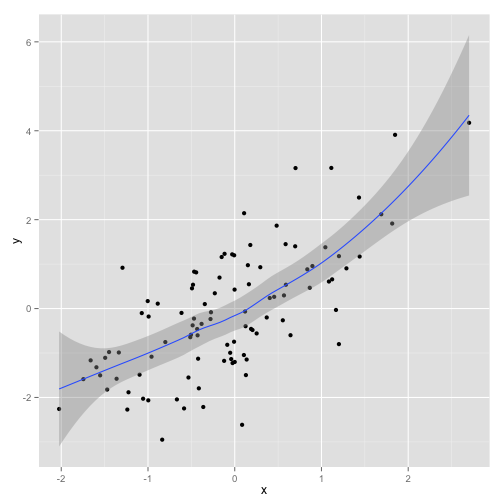

```r
x <- rnorm(100)
y <- x + rnorm(100)
qplot(x, y, geom = c("point", "smooth"))
```